# HW4_Solution

Ignacia Mercadal

12/12/2019

Edited by Eugene Tan

The goal of this exercise is to evaluate the consequences of electric deregulation on the prices paid by consumers for electricity. For this, we will use data on prices that I downloaded from the EIA website (you can find the original data here).

First, load the price data in prices.csv and do the following to prepare the data for the analysis: • Change variable names and remove the first row. • Convert relevant values to numerical, removing commas if necessary. • The table in the last page contains information about the dates in which the wholesale and retail markets were deregulated in each state. For the wholesale market, deregulation means that the market was opened to entry by any firm owning a generator. For the retail market, deregulation means that any firm can sell electricity to final consumers, and use the former regulated utility’s distribution network to deliver it to its customers. Based on this table, create two dummies. – treated: takes the value 1 when the wholesale market was deregulated in that state and year. For example, the dummy will have the value 1 for NJ in 2004, and a value of 0 for ME in 1996. – Create a dummy ever ever_dereg that takes the value 1 if that state’s wholesale market was ever deregulated and another dummy ever rdereg that takes the value 1 if that state’s retail market was ever deregulated.

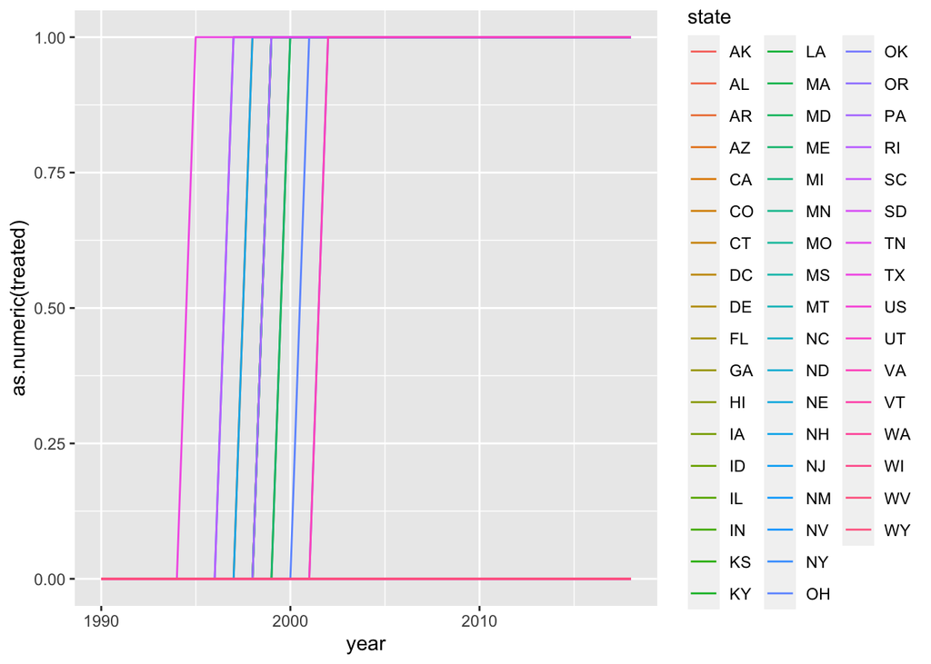

```r
## Load data ####
#setwd(".")

data <- data.table(read.csv("price.csv", stringsAsFactors=F))

setnames(data,  c("year", "state", "industry_sector", "residential", "commercial", "industrial", "transportation", "other", "total"))
#
data <- data[-1]
data[, residential := as.numeric(residential)]
data[, commercial := as.numeric(gsub(",","",commercial))]
data[, industrial := as.numeric(industrial)]
data[, transportation := as.numeric(transportation)]
data[, other := as.numeric(other)]
data[, total := as.numeric(total)]
data[, year := as.numeric(year)]

## Wholesale deregulation
data[, treated := 0]
data[state %in% c("TX") & year >= 1995, treated := 1]
data[state %in% c("RI", "NY") & year >= 1997, treated := 1]
data[state %in% c("CA", "NH") & year >= 1998, treated := 1]
data[state %in% c("MA", "PA", "NJ", "DE", "MD", "CT") &
        year >= 1999, treated := 1]
data[state %in% c("IL", "ME") & year >= 2000, treated := 1]
data[state %in% c("OH") & year >= 2001, treated := 1]
data[state %in% c("VA", "OR") & year >= 2002, treated := 1]
data[state %in% c("RI", "NY") & year >= 1997, treated := 1]

## Ever deregulated
data[, ever_dereg := max(treated), by = state]
data[, treated := as.logical(treated)]
data[, ever_dereg := as.logical(ever_dereg)]
#data[, treated := factor(treated, labels=c("Regulated", "Deregulated") )]
#data[, ever_dereg := factor(ever_dereg, labels=c("Regulated", "Deregulated") )]

# Look at the treatement
setkey(data,state,year)
ggplot(data[,.(treated),.(state, year)]) +
  geom_line(aes(x = year, y = as.numeric(treated), colour = state))
```

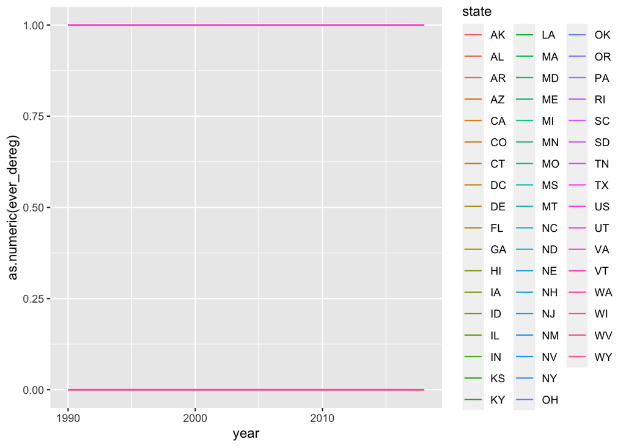

```r
# Look at ever dereg
ggplot(data[,.(ever_dereg),.(state, year)]) +
  geom_line(aes(x = year, y = as.numeric(ever_dereg), colour = state))
```

```r
# Observe the industry sectors
data[,unique(industry_sector)]
```

```
## [1] "Total Electric Industry"
## [2] "Full-Service Providers"
## [3] "Restructured Retail Service Providers"
## [4] "Energy-Only Providers"
## [5] "Delivery-Only Service"
```

2. Select the data where the industry sector category is the ”Total Electric Industry” and plot the evolution of prices over time using a separate line for states that were deregulated and states that were not deregulated (you can use the dummy ever ever_dereg created above). Do a separate plot for residential, commercial, and industrial customers

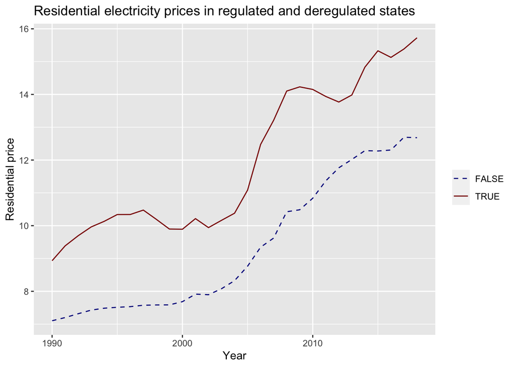

```r
data_plot <- copy(data[industry_sector == "Total Electric Industry"])
data_plot[, mean_pr := mean(residential), by = list(year, ever_dereg)]
data_plot[, mean_pc := mean(commercial), by = list(year, ever_dereg)]
data_plot[, mean_pi := mean(industrial), by = list(year, ever_dereg)]
data_plot <- unique(data_plot[, list(year, ever_dereg, mean_pr, mean_pc, mean_pi)])

ggplot(data_plot, aes(x=year, y=mean_pr, color=ever_dereg, linetype=ever_dereg)) +
  geom_line() + xlab("Year") + ylab("Residential price") +
  guides(color=guide_legend(title="")) +
  scale_color_manual("", values=c("Dark blue", "Dark red"))+
  scale_linetype_manual("", values=c("dashed", "solid")) +
  ggtitle("Residential electricity prices in regulated and deregulated states")
```

For commercial customers

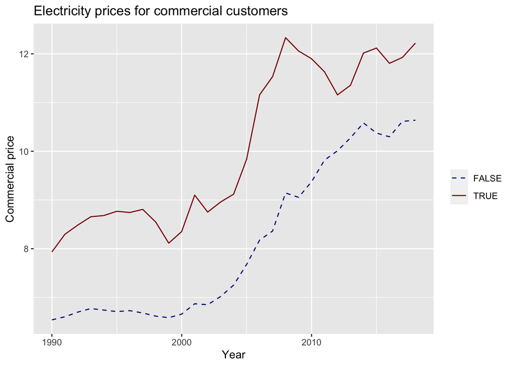

```r
ggplot(data_plot, aes(x=year, y=mean_pc, color=ever_dereg, linetype=ever_dereg)) +
  geom_line() + xlab("Year") + ylab("Commercial price") +
  guides(color=guide_legend(title="")) +
  scale_color_manual("", values=c("Dark blue", "Dark red"))+
  scale_linetype_manual("", values=c("dashed", "solid")) +
  ggtitle("Electricity prices for commercial customers")
```

For industrial customers

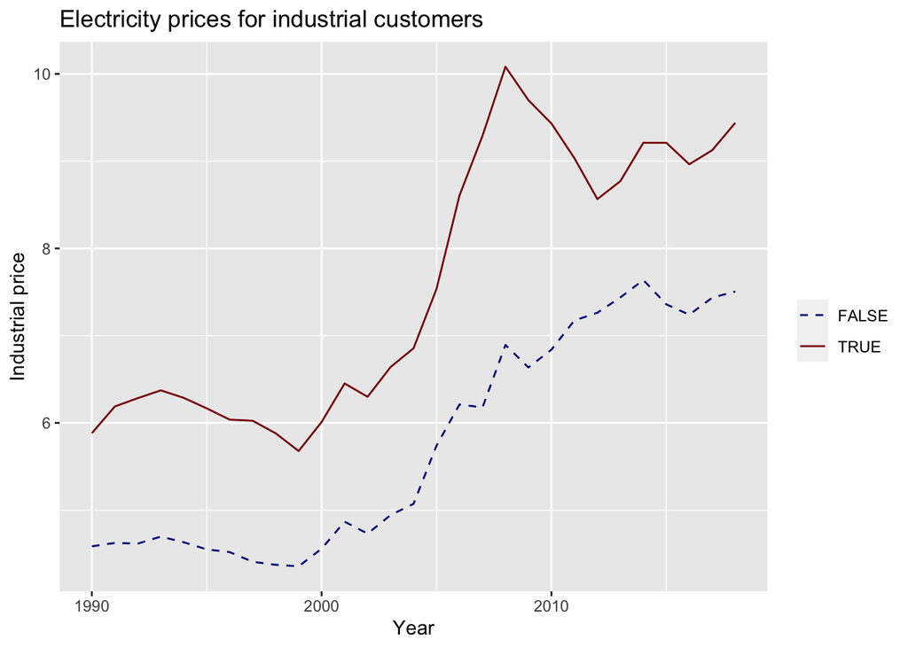

For all types of customers, states that deregulated had higher prices even before deregulation.

3. Run a regression of price on deregulation status, separately for wholesale and retail deregulation, and for both residential and industrial customers. What do you find?